# Analyse de les probabilités de détection du lynx

2026-06-10

## Import librairies

```r
#importation tidyverse

library(readr)
library(tidyr)
library(dplyr)
```

```r
library(ggplot2)
library(tibble)
library(stringr)
library(forcats)
library(lubridate)
#importation des autres librairies

library(emmeans)
library(glmmTMB)
library(bbmle)
library(blme)
library(lme4)
library(lmerTest)
library(MuMIn)
library(performance)
library(ggeffects)
library(effects)
library(ggsignif)

library(car)
```

## Fonctions utiles

```r
# Fonction de calcul des indices de surdispersion

overdisp_fun <- function(model) {
  rdf <- df.residual(model)
  rp <- residuals(model,type="pearson")
  Pearson.chisq <- sum(rp^2)
  prat <- Pearson.chisq/rdf
  pval <- pchisq(
    Pearson.chisq,
    df=rdf,
    lower.tail=FALSE
  )
  c(
    chisq=Pearson.chisq,
    ratio=prat,
    rdf=rdf,
    p=pval
  )
}
```

## Import données

```r
Tidy_Detection_Semaines <- read_csv("Data/Tidy_Detection_Semaines.csv")
View(Tidy_Detection_Semaines)

Tidy_Detection_Semaines$num_semaine <- as.factor(Tidy_Detection_Semaines$num_semaine)
Tidy_Detection_Semaines$semaine_piege <- as.factor(Tidy_Detection_Semaines$semaine_piege)
Tidy_Detection_Semaines$MS <- as.factor(Tidy_Detection_Semaines$MS)
Tidy_Detection_Semaines$PE <- as.factor(Tidy_Detection_Semaines$PE)

Tidy_Detection_Semaines$support <- as.factor(Tidy_Detection_Semaines$support)
Tidy_Detection_Semaines$typepiege <- as.factor(Tidy_Detection_Semaines$typepiege)
Tidy_Detection_Semaines$typelieu <- as.factor(Tidy_Detection_Semaines$typelieu)
Tidy_Detection_Semaines$odorant <- as.factor(Tidy_Detection_Semaines$odorant)
```

## Création du modèle ombrelle

```r
modele_ombrelle <- glmmTMB(
  detection ~
    typepiege +
    PE +
    typelieu +
    nb_jours_fonctionnement +
    ecart_attractif +
    hauteur_camera_cm +
    support +
    odorant +
    (1 | MS),
  data = Tidy_Detection_Semaines,
  family = binomial(link = 'logit')
  )
```

```
## dropping columns from rank-deficient conditional model: odorantLavande_Sansodorant, odorantLavande_Urine
```

```r
summary(modele_ombrelle)
```

```
##  Family: binomial  ( logit )
## Formula:
## detection ~ typepiege + PE + typelieu + nb_jours_fonctionnement +
##     ecart_attractif + hauteur_camera_cm + support + odorant +      (1 | MS)
## Data: Tidy_Detection_Semaines
##
##       AIC       BIC    logLik -2*log(L)  df.resid
##     662.6     723.3    -318.3     636.6       777
##
## Random effects:
##
## Conditional model:
##  Groups Name        Variance Std.Dev.
##  MS     (Intercept) 0.2696   0.5193
## Number of obs: 790, groups:  MS, 24
##
## Conditional model:
##                             Estimate Std. Error z value Pr(>|z|)
## (Intercept)                -1.160018   1.280637  -0.906 0.365035
## typepiegebrosse            -0.094450   0.493303  -0.191 0.848163
## PE2                         0.373382   0.241722   1.545 0.122425
## PE3                        -0.474861   0.271296  -1.750 0.080059 .
## typelieuN                  -1.559492   0.659761  -2.364 0.018092 *
## typelieuP                  -1.455358   0.651532  -2.234 0.025500 *
## nb_jours_fonctionnement     0.002142   0.154288   0.014 0.988922
## ecart_attractif             0.084756   0.022049   3.844 0.000121 ***
## hauteur_camera_cm          -0.007653   0.009670  -0.791 0.428730
## supportPiquet               0.400085   0.433706   0.922 0.356279
## supportRocher               0.440815   0.537680   0.820 0.412304
## odorantCastoreum_Urine      0.096978   0.660976   0.147 0.883354
## odorantLavande_Sansodorant        NA         NA      NA       NA
## odorantLavande_Urine              NA         NA      NA       NA
## ---
## Signif. codes:  0 '***' 0.001 '**' 0.01 '*' 0.05 '.' 0.1 ' ' 1
```

## AICc et sélection des modèles

Générations des modèles à partir du modèle ombrelle :

```r
options(na.action = "na.fail")
modeles_AICc = dredge(modele_ombrelle)
```

```
## Fixed terms are "cond((Int))" and "disp((Int))"
```

[output not shown]

[output not shown]

[output not shown]

Récupération des meilleurs modèles ayant : $\Delta AICc <2$

```r
modeles_selection = get.models(
  modeles_AICc,
  subset = delta < 2)

length(modeles_selection) #nombre de modeles retenus
```

```
## [1] 2
```

Moyennage des modèles :

```r
moy_modeles = model.avg(modeles_selection)
summary(moy_modeles)
```

```
##
## Call:
## model.avg(object = modeles_selection)
##
## Component model call:
## glmmTMB(formula = detection ~ <2 unique rhs>, data =
##      Tidy_Detection_Semaines, family = binomial(link = "logit"), ziformula =
##      ~0, dispformula = ~1)
##
## Component models:
##      df  logLik   AICc delta weight
## 134   7 -319.22 652.59  0.00   0.69
## 1234  8 -319.03 654.24  1.64   0.31
##
## Term codes:
##   cond(ecart_attractif) cond(hauteur_camera_cm)                cond(PE)
##                       1                       2                       3
##          cond(typelieu)
##                       4
##
## Model-averaged coefficients:
## (full average)
##                          Estimate Std. Error Adjusted SE z value Pr(>|z|)
## cond((Int))             -1.344640   0.459728    0.460358   2.921 0.003491 **
## cond(ecart_attractif)    0.084773   0.022031    0.022066   3.842 0.000122 ***
## cond(PE2)                0.375054   0.241538    0.241912   1.550 0.121052
## cond(PE3)               -0.475358   0.271249    0.271669   1.750 0.080159 .
## cond(typelieuN)         -1.334390   0.386693    0.387287   3.445 0.000570 ***
## cond(typelieuP)         -1.269422   0.385388    0.385982   3.289 0.001006 **
## cond(hauteur_camera_cm) -0.001677   0.005452    0.005458   0.307 0.758611
##
## (conditional average)
##                          Estimate Std. Error Adjusted SE z value Pr(>|z|)
## cond((Int))             -1.344640   0.459728    0.460358   2.921 0.003491 **
## cond(ecart_attractif)    0.084773   0.022031    0.022066   3.842 0.000122 ***
## cond(PE2)                0.375054   0.241538    0.241912   1.550 0.121052
## cond(PE3)               -0.475358   0.271249    0.271669   1.750 0.080159 .
## cond(typelieuN)         -1.334390   0.386693    0.387287   3.445 0.000570 ***
## cond(typelieuP)         -1.269422   0.385388    0.385982   3.289 0.001006 **
## cond(hauteur_camera_cm) -0.005491   0.008738    0.008751   0.627 0.530389
## ---
## Signif. codes:  0 '***' 0.001 '**' 0.01 '*' 0.05 '.' 0.1 ' ' 1
```

On fait un test Anova pour savoir quelles paramètres conservé par le modèle average ont des effets significatifs :

```r
modele_anova <- glmmTMB(
  detection ~
    typelieu +
    PE +
    ecart_attractif +
    hauteur_camera_cm +
    (1 | MS),
  data = Tidy_Detection_Semaines,
  family = binomial(link = 'logit'),
  )

Anova(modele_anova, type="III")
```

```
## Analysis of Deviance Table (Type III Wald chisquare tests)
##
## Response: detection
##                     Chisq Df Pr(>Chisq)
## (Intercept)        3.1785  1  0.0746140 .
## typelieu          15.7420  2  0.0003816 ***
## PE                 8.3452  2  0.0154124 *
## ecart_attractif   14.8178  1  0.0001184 ***
## hauteur_camera_cm  0.3949  1  0.5297520
## ---
## Signif. codes:  0 '***' 0.001 '**' 0.01 '*' 0.05 '.' 0.1 ' ' 1
```

Il y a donc un effet significatif de PE, typelieu et ecart_attractif. On conserve donc ces paramètres pour le modèle final sur lequel portera nos conclusions.

## Calcul d’un indice de dispersion

On calcule un indice de dispersion pour vérifier s’il y a une surdispersion des données et adapter le modèle le cas échéant.

```r
overdisp_fun(modele_ombrelle)
```

```
##       chisq       ratio         rdf           p
## 726.7906329   0.9353805 777.0000000   0.9006369
```

On obtient une p-value>0.05, donc il n’y a pas de sur-dispersion de notre modèle ombrelle. De plus, on faisant ce test sur tous les modèles sélectionnés, on observe qu’il n’y a pas non plus de sur-dispersion des données. Le test est également négatif pour modele_anova.

## Prise en compte des interactions

Au final, il y a eu 3 paramètres qui on eu des effets significatifs sur la détection de poils de lynx : période (PE), ecart_attractif et typelieu. Il va donc falloir tester les intercations : - PE:ecart_attractif - PE:typelieu - ecart_attractif:typelieu

On rajoute donc à notre modèle ombrelle les interactions entre les paramètres ayant été montrés significatifs par l’anova :

```r
modele_ombrelle_int <- glmmTMB(
  detection ~
    typepiege +
    support +
    odorant +
    typelieu +
    PE +
    nb_jours_fonctionnement +
    ecart_attractif +
    hauteur_camera_cm +
    PE:typelieu +
    PE:ecart_attractif +
    typelieu:ecart_attractif +
    (1 | MS),
  data = Tidy_Detection_Semaines,
  family = binomial(link = 'logit'),
  )
```

```
## dropping columns from rank-deficient conditional model: odorantLavande_Urine, typelieuP
```

```r
summary(modele_ombrelle_int)
```

```
##  Family: binomial  ( logit )
## Formula:
## detection ~ typepiege + support + odorant + typelieu + PE + nb_jours_fonctionnement +
##     ecart_attractif + hauteur_camera_cm + PE:typelieu + PE:ecart_attractif +
##     typelieu:ecart_attractif + (1 | MS)
## Data: Tidy_Detection_Semaines
##
##       AIC       BIC    logLik -2*log(L)  df.resid
##     664.9     763.0    -311.5     622.9       769
##
## Random effects:
##
## Conditional model:
##  Groups Name        Variance Std.Dev.
##  MS     (Intercept) 0.3032   0.5507
## Number of obs: 790, groups:  MS, 24
##
## Conditional model:
##                            Estimate Std. Error z value Pr(>|z|)
## (Intercept)                -2.50387    1.46698  -1.707   0.0879 .
## typepiegebrosse             1.03551    0.78792   1.314   0.1888
## supportPiquet               0.41196    0.45029   0.915   0.3603
## supportRocher               0.44056    0.55946   0.787   0.4310
## odorantCastoreum_Urine     -1.03542    0.75402  -1.373   0.1697
## odorantLavande_Sansodorant  1.14506    0.85517   1.339   0.1806
## odorantLavande_Urine             NA         NA      NA       NA
## typelieuN                  -0.30680    0.73074  -0.420   0.6746
## typelieuP                        NA         NA      NA       NA
## PE2                         1.08752    0.49282   2.207   0.0273 *
## PE3                         0.29326    0.61650   0.476   0.6343
## nb_jours_fonctionnement    -0.01936    0.16084  -0.120   0.9042
## ecart_attractif             0.11126    0.04333   2.568   0.0102 *
## hauteur_camera_cm          -0.00816    0.01005  -0.812   0.4167
## typelieuN:PE2              -0.09139    0.60426  -0.151   0.8798
## typelieuP:PE2              -1.36809    0.61538  -2.223   0.0262 *
## typelieuN:PE3               0.16385    0.69859   0.234   0.8146
## typelieuP:PE3              -1.65702    0.90058  -1.840   0.0658 .
## PE2:ecart_attractif        -0.04117    0.04796  -0.859   0.3906
## PE3:ecart_attractif        -0.09169    0.09318  -0.984   0.3251
## typelieuN:ecart_attractif  -0.02840    0.05620  -0.505   0.6134
## typelieuP:ecart_attractif   0.03463    0.05621   0.616   0.5378
## ---
## Signif. codes:  0 '***' 0.001 '**' 0.01 '*' 0.05 '.' 0.1 ' ' 1
```

Calcul d’AIC des différents modèle possibles, obtenus à partir du modèle ombrelle :

```r
options(na.action = "na.fail")
modeles_AICc_int = dredge(modele_ombrelle_int)
```

```
## Fixed terms are "cond((Int))" and "disp((Int))"
```

[output not shown]

[output not shown]

[output not shown]

[output not shown]

[output not shown]

[output not shown]

[output not shown]

[output not shown]

[output not shown]

[output not shown]

[output not shown]

[output not shown]

[output not shown]

[output not shown]

[output not shown]

[output not shown]

[output not shown]

[output not shown]

Récupération des meilleurs modèles ayant : $\Delta AICc <2$

```r
modeles_selection_int = get.models(
  modeles_AICc_int,
  subset = delta < 2)

length(modeles_selection_int) #nombre de modeles retenus
```

```
## [1] 2
```

Moyennage des modèles :

```r
moy_modeles_int = model.avg(modeles_selection_int)
summary(moy_modeles_int)
```

```
##
## Call:
## model.avg(object = modeles_selection_int)
##
## Component model call:
## glmmTMB(formula = detection ~ <2 unique rhs>, data =
##      Tidy_Detection_Semaines, family = binomial(link = "logit"), ziformula =
##      ~0, dispformula = ~1)
##
## Component models:
##       df  logLik   AICc delta weight
## 1345  11 -313.78 649.90  0.00   0.69
## 12345 12 -313.56 651.53  1.63   0.31
##
## Term codes:
##   cond(ecart_attractif) cond(hauteur_camera_cm)                cond(PE)
##                       1                       2                       3
##          cond(typelieu)       cond(PE:typelieu)
##                       4                       5
##
## Model-averaged coefficients:
## (full average)
##                          Estimate Std. Error Adjusted SE z value Pr(>|z|)
## cond((Int))             -1.523969   0.487673    0.488344   3.121  0.00180 **
## cond(ecart_attractif)    0.085719   0.022573    0.022608   3.792  0.00015 ***
## cond(PE2)                0.800720   0.358776    0.359335   2.228  0.02586 *
## cond(PE3)               -0.228501   0.355172    0.355724   0.642  0.52064
## cond(typelieuN)         -1.425670   0.494313    0.495077   2.880  0.00398 **
## cond(typelieuP)         -0.640338   0.446773    0.447466   1.431  0.15242
## cond(PE2:typelieuN)     -0.089253   0.600608    0.601543   0.148  0.88205
## cond(PE3:typelieuN)      0.436883   0.624017    0.624988   0.699  0.48454
## cond(PE2:typelieuP)     -1.417538   0.605394    0.606337   2.338  0.01939 *
## cond(PE3:typelieuP)     -1.715219   0.843380    0.844693   2.031  0.04230 *
## cond(hauteur_camera_cm) -0.001791   0.005649    0.005655   0.317  0.75145
##
## (conditional average)
##                          Estimate Std. Error Adjusted SE z value Pr(>|z|)
## cond((Int))             -1.523969   0.487673    0.488344   3.121  0.00180 **
## cond(ecart_attractif)    0.085719   0.022573    0.022608   3.792  0.00015 ***
## cond(PE2)                0.800720   0.358776    0.359335   2.228  0.02586 *
## cond(PE3)               -0.228501   0.355172    0.355724   0.642  0.52064
## cond(typelieuN)         -1.425670   0.494313    0.495077   2.880  0.00398 **
## cond(typelieuP)         -0.640338   0.446773    0.447466   1.431  0.15242
## cond(PE2:typelieuN)     -0.089253   0.600608    0.601543   0.148  0.88205
## cond(PE3:typelieuN)      0.436883   0.624017    0.624988   0.699  0.48454
## cond(PE2:typelieuP)     -1.417538   0.605394    0.606337   2.338  0.01939 *
## cond(PE3:typelieuP)     -1.715219   0.843380    0.844693   2.031  0.04230 *
## cond(hauteur_camera_cm) -0.005845   0.008968    0.008982   0.651  0.51519
## ---
## Signif. codes:  0 '***' 0.001 '**' 0.01 '*' 0.05 '.' 0.1 ' ' 1
```

Test ANOVA pour les interactions ayant été conservées dans le modèle average :

```r
modele_anova2 <- glmmTMB(
  detection ~ PE +
    typelieu +
    ecart_attractif +
    PE:typelieu +
    (1 | MS),
  data = Tidy_Detection_Semaines,
  family = binomial(link = 'logit')
  )

Anova(modele_anova2, type="III")
```

```
## Analysis of Deviance Table (Type III Wald chisquare tests)
##
## Response: detection
##                   Chisq Df Pr(>Chisq)
## (Intercept)     22.7112  1  1.883e-06 ***
## PE               7.6247  2  0.0220963 *
## typelieu         8.2966  2  0.0157912 *
## ecart_attractif 14.4168  1  0.0001465 ***
## PE:typelieu      9.8516  4  0.0430029 *
## ---
## Signif. codes:  0 '***' 0.001 '**' 0.01 '*' 0.05 '.' 0.1 ' ' 1
```

Il y a donc bien une interaction significative. Elle sera donc inclue dans notre modèle final.

On calcul un indice de dispersion pour vérifier s’il y a une surdispersion des données et adapter le modèle le cas échéant.

```r
overdisp_fun(modele_ombrelle_int)
```

```
##       chisq       ratio         rdf           p
## 717.0799638   0.9324837 769.0000000   0.9095246
```

On obtient une p-value>0.05, donc il n’y a pas de sur-dispersion de notre modèle ombrelle. Il en est de même pour modele_anova2.

## Création d’un nouveau modèles simplifié

On créé un modèle final avec tous les paramètres et interactions ayant été montrés significatifs précédemment.

```r
modele_final <- glmmTMB(
  detection ~ PE +
    typelieu +
    ecart_attractif +
    typelieu:PE +
    (1 | MS),
  data = Tidy_Detection_Semaines,
  family = binomial(link = 'logit')
  )
```

On calcul un indice de dispersion pour vérifier s’il y a une surdispersion des données et adapter le modèle le cas échéant.

```r
overdisp_fun(modele_final)
```

```
##       chisq       ratio         rdf           p
## 715.4502635   0.9184214 779.0000000   0.9493931
```

On obtient une p-value>0.05, donc il n’y a pas de sur-dispersion de notre modèle.

## Calcul du coefficient de détermination marginal

```r
r2(modele_final)
```

```
## # R2 for Mixed Models
##
##   Conditional R2: 0.287
##      Marginal R2: 0.216
```

```r
check_singularity(modele_final)
```

```
## [1] FALSE
```

Pas de singularité. 21,6% de la variance est expliquée par les paramètres pris en compte dans le modèle.

## Interprétation du modèle final

```r
summary(modele_final)
```

```
##  Family: binomial  ( logit )
## Formula:
## detection ~ PE + typelieu + ecart_attractif + typelieu:PE + (1 |      MS)
## Data: Tidy_Detection_Semaines
##
##       AIC       BIC    logLik -2*log(L)  df.resid
##     649.6     701.0    -313.8     627.6       779
##
## Random effects:
##
## Conditional model:
##  Groups Name        Variance Std.Dev.
##  MS     (Intercept) 0.3246   0.5698
## Number of obs: 790, groups:  MS, 24
##
## Conditional model:
##                 Estimate Std. Error z value Pr(>|z|)
## (Intercept)     -1.63456    0.34299  -4.766 1.88e-06 ***
## PE2              0.79964    0.35873   2.229 0.025810 *
## PE3             -0.22865    0.35517  -0.644 0.519712
## typelieuN       -1.40004    0.48746  -2.872 0.004077 **
## typelieuP       -0.62313    0.44338  -1.405 0.159904
## ecart_attractif  0.08570    0.02257   3.797 0.000146 ***
## PE2:typelieuN   -0.08845    0.60051  -0.147 0.882904
## PE3:typelieuN    0.43684    0.62395   0.700 0.483852
## PE2:typelieuP   -1.41649    0.60541  -2.340 0.019298 *
## PE3:typelieuP   -1.71495    0.84342  -2.033 0.042018 *
## ---
## Signif. codes:  0 '***' 0.001 '**' 0.01 '*' 0.05 '.' 0.1 ' ' 1
```

On observe un que plus l’ecart_attractif est important, plus on a de chances de détecter un lynx au cours de la semaine.

```r
emmeans(modele_final, ~typelieu:PE)
```

```
##  typelieu PE emmean    SE  df asymp.LCL asymp.UCL
##  B        1  -1.163 0.301 Inf     -1.75    -0.573
##  N        1  -2.563 0.393 Inf     -3.33    -1.793
##  P        1  -1.786 0.337 Inf     -2.45    -1.126
##  B        2  -0.363 0.347 Inf     -1.04     0.318
##  N        2  -1.852 0.418 Inf     -2.67    -1.032
##  P        2  -2.403 0.482 Inf     -3.35    -1.459
##  B        3  -1.391 0.342 Inf     -2.06    -0.721
##  N        3  -2.355 0.457 Inf     -3.25    -1.459
##  P        3  -3.729 0.765 Inf     -5.23    -2.230
##
## Results are given on the logit (not the response) scale.
## Confidence level used: 0.95
```

## Représentation graphique des résultats

Représentation graphique récapitulant tout les résultats :

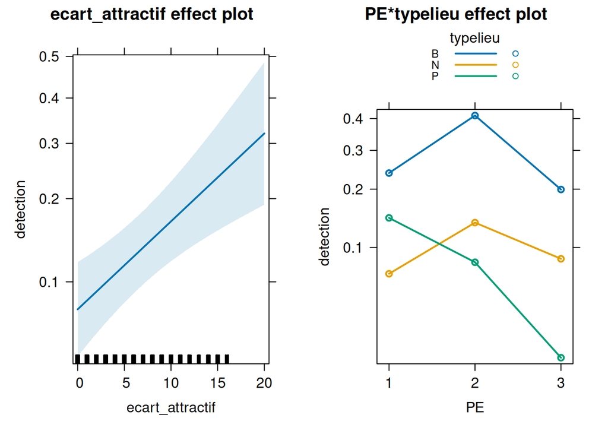

```r
eff <- allEffects(modele_final)
plot(eff, multiline = TRUE)
```

Représentation des effets significatifs uns à uns :

```r
predecart_attractif <- ggpredict(
          modele_final,
          terms = "ecart_attractif",
          bias_correction = TRUE
          )
```

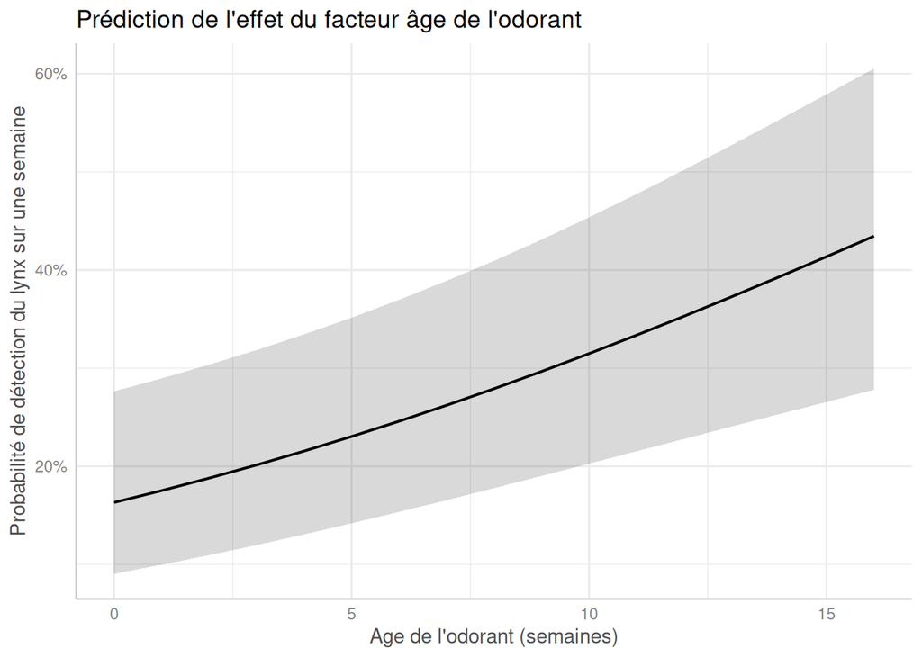

```r
plot(
  predecart_attractif) +
  labs(
    title = "Prédiction de l'effet du facteur âge de l'odorant",
    x = "Age de l'odorant (semaines)",
    y = "Probabilité de détection du lynx sur une semaine"
    )
```

```r
ggsave(filename = "Plots/Probabilite_detection_lynx/Prediction_Detection_Lynx_ecart_attractif.jpg")
```

Ces résultats peuvent être expliqués par le fait qu’à la pose d’un nouvel attractif, il y a perturbation de l’environnement (par exemple des traces d’odeur humaine) qui peut faire fuir les lynx.

```r
predPE_typelieu <- ggpredict(
          modele_final,
          terms = c("typelieu","PE"),
          bias_correction = TRUE
          )
```

```
## Ignoring unknown labels:
## • linetype : "PE"
## • shape : "PE"
```

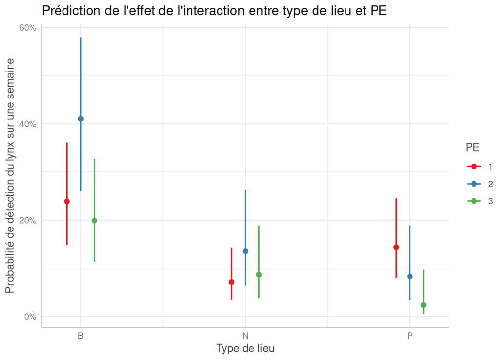

```r
plot(
  predPE_typelieu) +
  labs(
    title = "Prédiction de l'effet de l'interaction entre type de lieu et PE",
    x = "Type de lieu",
    y = "Probabilité de détection du lynx sur une semaine"
    )
```

```r
ggsave(filename = "Plots/Probabilite_detection_lynx/Prediction_Detection_Lynx_int_PE_typelieu.jpg")
```

```
## Ignoring unknown labels:
## • linetype : "PE"
## • shape : "PE"
```